# Milestone_Report

# Executive Summary

The capstone project aims to demonstrate the ability to process and analyze large volumes of unstructured text. As a final deliverable, the data scientist will develop an algorithm that predicts the next word in a provided text, similar to the predictive text functions found on today’s modern smart phones.

This report demonstrates the data scientist’s ability to successfully import the text data into R, provide basic summary statistics, and explain the planned steps for producing an algorithm for text prediction.

Libraries used:

```r
library(ngram)
library(R.utils)
library(tm)
```

```r
library(SnowballC)
library(stringr)
library(ggplot2)
library(dplyr)
```

# Getting data

We’ll begin this by downloading the data

```r
        fileurl <- "https://d396qusza40orc.cloudfront.net/dsscapstone/dataset/Coursera-SwiftKey.zip"
        filename <- "Coursera-SwiftKey.zip"
        if(!file.exists(filename))
        {
                download.file(fileurl,destfile = filename)
        }

        if(!file.exists("final")) unzip(filename)
```

# Creating data corpus

Here we load the data into the local environment. We could alternatively just create a corpus using the corpus function but that would be significantly difficult to handle because of the sheer size of data.

```r
        twitter <- readLines("./final/en_us/en_US.twitter.txt", skipNul = T)
        blogs <- readLines("./final/en_us/en_US.blogs.txt", skipNul = T)
        news <- readLines("./final/en_us/en_US.news.txt", skipNul = T)
        complete <- c(blogs,news,twitter)
```

# Counting the number of words and lines

```r
        word.count <- function(my.list) {sum(str_count(my.list, "\\S+"),na.rm = T ) }
        df <- data.frame(text.source = c("blogs", "twitter", "news"), line.count = NA, word.count = NA)
        my.list <- list(blog = blogs, twitter = twitter, news = news)
        # get line count and word count for each Corpura
        df$line.count <- sapply(my.list, length)
        df$word.count <- sapply(my.list, word.count)
        df
```

```
##   text.source line.count word.count
## 1       blogs     899288   37334441
## 2     twitter    2360148   30373832
## 3        news      77259    2643972
```

This data table shows the line count and the word count of all the three files. However, we cannot show all the individual word counts or line counts because there over 3 million entries.

# Data Exploration

Since we cannot explore the data as a whole we’ll use the principals from the regression models specifically the idea of sampling to represent the population. So we’ll use 100,000 random samples as a way to explore the population

```r
#Random selection

        set.seed(230)
        numbers <- sample(1:length(complete),100000)
        selected.data <- as.vector(complete[numbers])
        Corpus <- VCorpus(VectorSource((selected.data)))
```

Now we’ll clean the data

```r
#cleaning the data(Preprocessing)
        toSpace <- content_transformer(function(x,pattern){ return(gsub(pattern," ",x))})

#Removing unimportant characters
        Corpus <- tm_map(Corpus,toSpace,"-")
        Corpus <- tm_map(Corpus,toSpace,":")
        Corpus <- tm_map(Corpus,toSpace,"`")
        Corpus <- tm_map(Corpus,toSpace,"'")
        Corpus <- tm_map(Corpus,toSpace," -")
        Corpus <- tm_map(Corpus,toSpace,"â€œ")
        Corpus <- tm_map(Corpus,toSpace,"â€™")
        Corpus <- tm_map(Corpus,toSpace,"â€˜")
        Corpus <- tm_map(Corpus,toSpace,"â€¦")
        Corpus <- tm_map(Corpus,toSpace,"â€")

#Removing Punctuation
        Corpus <- tm_map(Corpus, removePunctuation)

#Transform to lowercase
        Corpus <- tm_map(Corpus,content_transformer(tolower))

#Remove numbers
        Corpus <- tm_map(Corpus,removeNumbers)

#We also have to remove "profane" words
        filename2 <- "profane.csv"
        if(!file.exists(filename2)){
                download.file("http://www.bannedwordlist.com/lists/swearWords.csv",destfile=filename2,)
        }
        profanewords <- read.csv(filename2,header = FALSE)
        profanewords <- as.vector(profanewords)
        Corpus <- tm_map(Corpus,removeWords,profanewords)

#Remove white spaces
        Corpus <- tm_map(Corpus,stripWhitespace)

#Document Term Matrix

        dtm <- DocumentTermMatrix(Corpus)

#Removing highly in consequent words
#there are whole lot of words and a 100,000 observations, finding frequencies can't be done all at once
#let's find the best number to formulate these loops

        numberwords<-length(dtm$dimnames[2][[1]])
        loopnumber <- function(x){
                i=1000
                while(i <1100)
                if(x%%i!=0){
                        i=i+1
                }
                else{
                        return(i)
                }
        }
        index <- loopnumber(numberwords)
        loopend <- numberwords / index
        endingindex <- 0
        frequencymat <- matrix(NA,numberwords,1)
        for(i in 1:loopend){
        startindex <- i + endingindex
        endingindex<- i*index
        frequencymat[startindex:endingindex] <- colSums(as.matrix(dtm[,startindex:endingindex]))
        }
        summary(frequencymat)
```

```
##        V1
##  Min.   :    1.00
##  1st Qu.:    1.00
##  Median :    1.00
##  Mean   :   20.92
##  3rd Qu.:    4.00
##  Max.   :89543.00
##  NA's   :2628
```

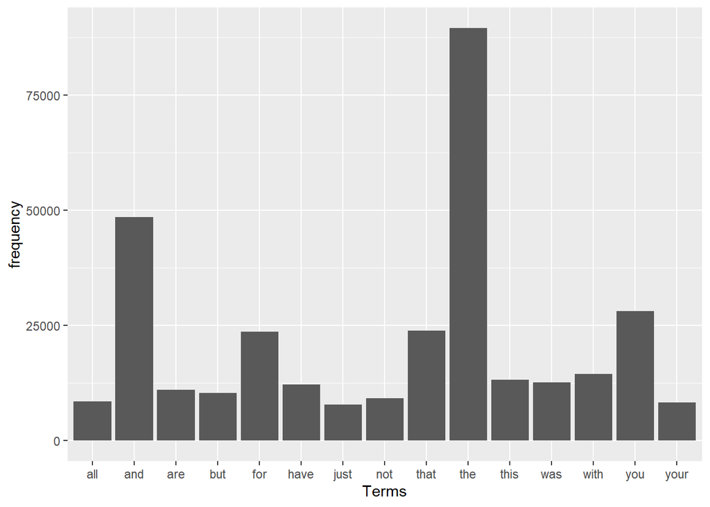

```r
        frequencydat <- data.frame(words = dtm$dimnames[2],frequency = frequencymat)

#We can plot the top 10 most frequent words
        sortfrequncydat <- frequencydat[complete.cases(frequencydat),]
        sortfrequncydat <- sortfrequncydat %>% arrange(desc(frequency))
        topfrequency <- head(sortfrequncydat,15)
        bottomfrequency <- tail(sortfrequncydat,15)

        g <- ggplot(data = topfrequency,aes(x=Terms,y=frequency))
        g2 <- ggplot(data = bottomfrequency,aes(x=Terms,y=frequency))
        g + geom_bar(stat="identity")
```

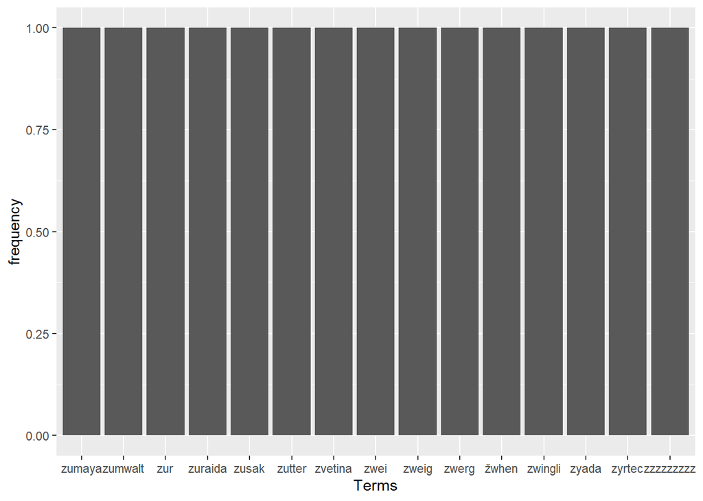

```r
        g2 +  geom_bar(stat = "identity")
```

This makes sense because words like “the” “and” are the most commonly used and should be recommended the most in our prediction system and the words at the bottom really don’t make too much sense and as we build our model these will have a lower significance.

# Goals and Algorithm

This data sufficiently gives us enough insight into our data. We have tokenised the data into a document term matrix and observed what kind of words should we see the most in our prediction of our system and which we shouldn’t. Now for the algorithm or the idea on which this project will be dividing the corpus on the into n-grams and then on the basis which n-gram model, for example unigram or bigram or trigram, gives the best prediction result, I’ll choose that as the prediction model.